# Презентация по лабораторной работе №3

Дискреционное разграничение прав в Linux. Два пользователя

Лушин А.А.

Российский университет дружбы народов, Москва, Россия

Факультет Физико-математических и естественных наук

18 февраля 2005

# Информация

## Докладчик

- Лушин Артём Андреевич
- Бакалавр направления компьютерные и информационные науки
- Кафедра теории вероятности и кибербезопасности
- Российский университет дружбы народов
- Редактор Первого Федерального канала
- lusin5745@gmail.com

# Вводная часть

## Цели и задачи

- Получение практических навыков работы в консоли с атрибутами файлов для групп пользователей

# Ход работы

## Создание новых пользователей

Для начала работы мы должны сделать новых пользователей. Нам понадобится 2 пользователя: guest, guest2. Сначала вводим команду для создания пользователя, затем создаём к нему пароль.

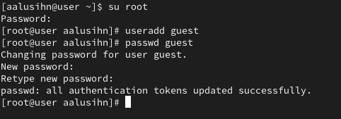

## Два пользователя одновременно

Для дальнейшей работы нам понадобится использовать сразу двух пользователей. Для этого открываем две консоли. В одной с помощью команды “su guest” заходим в одного пользователя. Затем во второй консоли с помощью команды “su guest2” заходим на второго пользователя. Важно, что консоли работают независимо друг от друга.

## Сверка данных и добавление в группы

С помощью команды “gpasswd -a guest2 guest” мы добавляем одного из пользователей в группу ко второму. С помощью команды “id -Gn” или “groups” мы можем проверить, что пользователь точно добавлен. Помимо этого сверяем и остальную информацию, чтобы не ошибаться.

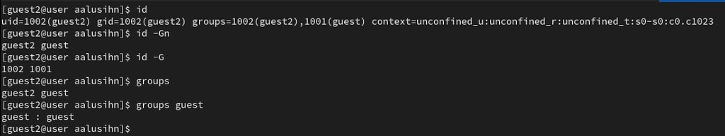

## Выдача прав для группы пользователей

У каждого файла есть 3 категории прав: для владельца файла (U), для группы (G) и для всех остальных (O). Чтобы второй пользователь мог использовать файлы первого пользователя, для категории “G” необходимо выдать все права. По ходу лабораторной работы мы выдали: rwx - read, write, exec. То есть второй пользователь мог использовать все функции директории.

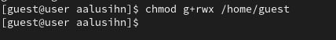

## Таблица 1

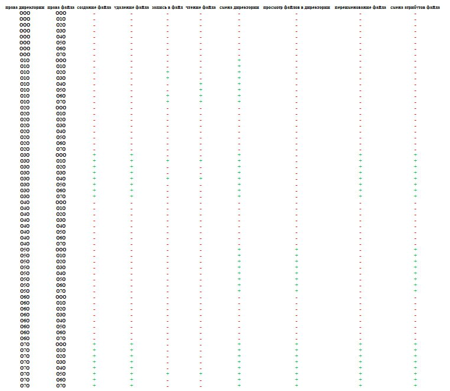

## Таблица 2

Так же мы заполнили вторую таблицу, которая основана на данных из первой таблицы. На пересечении определённых столбцов и строк стоят минимальные права, которые необходимы для выполнения данной функции.

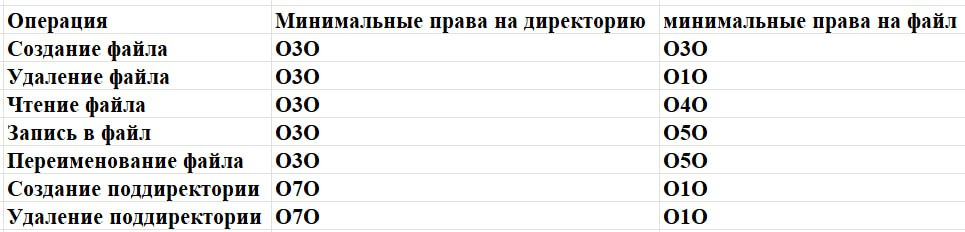

# Результаты

## Вывод

Я получил практические навыки работы в консоли с атрибутами файлов для групп пользователей.